# R Controlling logical flow

Kenny

Monday, January 12, 2015

### Making Choices with if Statements

> Instead of using a classic loop structure, you use a function to apply another function on any of the objects. This way of looping over values is one of the features that distinguishes R from many other programming languages.

```r
priceCalculator <- function(hours, pph=40){  # this is proper function
    net.price <- hours * pphs
    round(net.price)
}

priceCalculator <- function(hours, pph=40){
    net.price <- hours * pph
    if(hours > 100) {                        # same function include if to make a choice
      net.price <- net.price * 0.9
    }
    round(net.price)
}

priceCalculator(hours = 55)                # run the function with normal data
```

```
## [1] 2200
```

```r
priceCalculator(hours = 110)               # run function with data specified in the choice
```

```
## [1] 3960
```

```r
priceCalculator <- function(hours, pph=40){
    net.price <- hours * pph
    if(hours > 100) net.price <- net.price * 0.9   # same function with specific choice but if statment in simplified version without {}
    round(net.price)
}
```

### When to use if … else

> In some cases, you need your function to do something if a condition is true and something else if it is not.

> if(public == TRUE) is about as redundant as asking if white snow is white, if(public) is good coding

```r
priceCalculator <- function(hours, pph=40, public=TRUE){ # hours = necessity data, pph = constant,
                                                         # public = TRUE default setting and arg for if
                                                         # ...else situation
    net.price <- hours * pph
    if(hours > 100) net.price <- net.price * 0.9         # a free choice
    if(public) {                                         # yes choice from yes or no situation
      tot.price <- net.price * 1.06
    } else {                                             # no choice from yes or no situation
      tot.price <- net.price * 1.12
    }
    round(tot.price)
}

priceCalculator(25,public=TRUE)                          # 25 stands for hours, public = TRUE default
```

```
## [1] 1060
```

```r
priceCalculator(25,public=FALSE)                         # value no need mentioning, unless it is not
```

```
## [1] 1120
```

```r
                                                         # default but public = FALSE
```

> **make if…else statement shorter** Putting the else statement at the end of a line and not the beginning of the next one is a good idea. If you put else at the beginning of the second line, R considers the first line finished and complains.

```r
priceCalculator <- function(hours, pph=40, public=TRUE){
    net.price <- hours * pph
    if(hours > 100) net.price <- net.price * 0.9         # A short way of writing if statement
    if(public) tot.price <- net.price * 1.06 else        # a short way of writing if...else statement
               tot.price <- net.price * 1.12
    round(tot.price)
}
```

> **to make if…else statement even shorter**

```r
priceCalculator <- function(hours, pph=40, public=TRUE){
    net.price <- hours * pph
    if(hours > 100) net.price <- net.price * 0.9
    tot.price <- net.price * if(public) 1.06 else 1.12   # R will access if...else statement first
    round(tot.price)
}
```

### taking a vector of values together automatically not one value a time –Vectorizing Choices

> current function can only take one value at a time, but even two values together

```r
priceCalculator
```

```
## function(hours, pph=40, public=TRUE){
##     net.price <- hours * pph
##     if(hours > 100) net.price <- net.price * 0.9
##     tot.price <- net.price * if(public) 1.06 else 1.12   # R will access if...else statement first
##     round(tot.price)
## }
```

```r
priceCalculator(c(25,110))  # the problem is current function can only take one value not two
```

```
## [1] 1060 4664
```

```r
priceCalculator(110)
```

```
## [1] 4198
```

```r
c(25, 110) > 100            # both values have different criteria, one < 100, the other > 100
```

```
## [1] FALSE  TRUE
```

> if…else: yes and no for doing different things; ifelse: yes and no for selecting diff values  
> test for true or false on more than one value, there need more choices for selections

```r
ifelse(c(1,3) < 2.5, 1:2, 3:4) # the first value of second arg, the second value of third arg
```

```
## [1] 1 4
```

```r
ifelse(c(3,2) < 2.5, 1:2, 3:4) # the second value of second arg, the first value of third arg
```

```
## [1] 3 2
```

> example with only one ifelse

```r
my.hours <- c(25,110)

my.hours * 40 * ifelse(my.hours > 100, 0.9, 1) # yes and no for selecting diff values
```

```
## [1] 1000 3960
```

> function with two ifelse

```r
priceCalculator <- function(hours,pph=40,public){  # two args used in ifelse, pph = constant
    net.price <- hours * pph
    net.price <- net.price * ifelse(hours > 100 , 0.9, 1) # ifelse on hours
    tot.price <- net.price * ifelse(public, 1.06, 1.12)   # ifelse on public
    round(tot.price)
}

clients <- data.frame(                 # two args formulate features of each client
  hours = c(25, 110, 125, 40),         # There are four clients = four diff set of (two) args
  public = c(TRUE,TRUE,FALSE,FALSE)
)

with(clients, priceCalculator(hours, public = public))  # apply the data to function
```

```
## [1] 1060 4198 5040 1792
```

### What if there are Multiple Choices to choose from

> **Chaining/nesting if…else situation**

> three options: private, public and foreign, with three diff rates

> **most formal and lengthy way of coding**

```
if(client=='private'){
 tot.price <- net.price * 1.12      # 12% VAT
} else {
 if(client=='public'){
   tot.price <- net.price * 1.06    # 6% VAT
 } else {
   tot.price <- net.price * 1    # 0% VAT
 }
}
```

> **saved one pair of curly braces from else**

```
if(client=='private'){
   tot.price <- net.price * 1.12
} else if(client=='public'){          # one pair is saved here
   tot.price <- net.price * 1.06
} else {
   tot.price <- net.price
}
```

> **most efficient way of coding with nesting ifelse twice**

```
VAT <- ifelse(client=='private', 1.12,           # lots of curly braces saved
         ifelse(client == 'public', 1.06, 1)
      )
tot.price <- net.price * VAT
```

> **chained if…else statements can only on one value at a time, chained ifelse can work on vectors**  
> if there are more than two ifelse, then switch is needed

### Switching between three or more possibilities/choices

> equivalent to: if client = ‘private’, then VAT = 1.12; if client = public, then VAT = 1.06….

```
VAT <- switch(client, private=1.12, public=1.06, abroad=1)
```

> Using default values in switch: VAT = 1, 1 is default value for when client = ‘others’

```
VAT <- switch(client, private=1.12, public=1.06, 1)
```

```r
client <- 'other'
switch(client, private=1.12, public=1.06, 1)
```

```
## [1] 1
```

### Looping Through Values

```r
priceCalculator <- function(hours, pph=40, client){
    net.price <- hours * pph *
                   ifelse(hours > 100, 0.9, 1)

    VAT <- numeric(0)  # to make sure 0 is 0L
    for(i in client){
      VAT <- c(VAT,switch(i, private=1.12, public=1.06, 1))
    }

    tot.price <- net.price * VAT
    round(tot.price)
}


clients$type <- c('public','abroad','private','abroad')
clients$hours
```

```
## [1]  25 110 125  40
```

```r
priceCalculator(clients$hours, client=clients$type)
```

```
## [1] 1060 3960 5040 1600
```

### Using loops and indices

```r
client
```

```
## [1] "other"
```

```r
nclient <- length(client)
VAT <- numeric(nclient)
for(i in seq_along(client)){  # i will be 1, 2, 3, ...
  VAT[i] <- switch(client[i], private=1.12, public=1.06, 1)
}

seq_along(client)
```

```
## [1] 1
```

```r
seq_along(c("a", "b", "z"))
```

```
## [1] 1 2 3
```

```r
VAT
```

```
## [1] 1
```

### Looping without Loops: Meeting the Apply Family

> for loop has a serious side effect

```r
songline <- 'Get out of my dreams...'
for(songline in 1:5) print('...Get into my car!')
```

```
## [1] "...Get into my car!"
## [1] "...Get into my car!"
## [1] "...Get into my car!"
## [1] "...Get into my car!"
## [1] "...Get into my car!"
```

```r
songline
```

```
## [1] 5
```

> Although you never explicitly changed the value of songline anywhere in the code, R does so implicitly when carrying out the for loop. Every iteration, R reassigns the next value from the vector to songline . . . in the workspace!

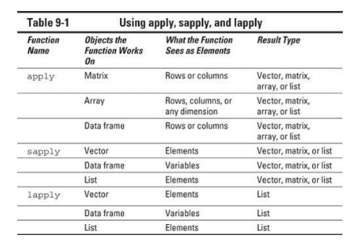

### Applying functions on rows and columns

```r
counts <- matrix(c(3,2,4,6,5,1,8,6,1), ncol=3) # create a matrix
colnames(counts) <- c('sparrow','dove','crow') # give col names
counts
```

```
##      sparrow dove crow
## [1,]       3    6    8
## [2,]       2    5    6
## [3,]       4    1    1
```

```r
apply(counts, 2, max) # apply max function to every cols
```

```
## sparrow    dove    crow
##       4       6       8
```

### Adding extra arguments

```r
counts[2, 2] <- NA
apply(counts,2,max) # NA affect applying function
```

```
## sparrow    dove    crow
##       4      NA       8
```

```r
apply(counts, 2, max, na.rm=TRUE) # it is working
```

```
## sparrow    dove    crow
##       4       6       8
```

### Applying functions to listlike objects

```r
sapply(c('a','b'), switch, a='Hello', b='Goodbye')
```

```
##         a         b
##   "Hello" "Goodbye"
```

#### Replacing a complete for loop with a single statement

```r
priceCalculator <- function(hours, pph=40, client){
  net.price <- hours * pph * ifelse(hours > 100, 0.9, 1)

  VAT <- sapply(client, switch, private=1.12, public=1.06, 1)

  tot.price <- net.price * VAT
  round(tot.price)
}

myClient <- c("private", "public", "other")
priceCalculator(20, client = myClient )
```

```
## private  public   other
##     896     848     800
```

### Applying a function to a data frame

```r
clients
```

```
##   hours public    type
## 1    25   TRUE  public
## 2   110   TRUE  abroad
## 3   125  FALSE private
## 4    40  FALSE  abroad
```

```r
sapply(clients,class)
```

```
##       hours      public        type
##   "numeric"   "logical" "character"
```

```r
sapply(clients, mean)
```

```
##  hours public   type
##   75.0    0.5     NA
```

### Simplifying results (or not) with sapply

```r
sapply(clients, unique)
```

```
## $hours
## [1]  25 110 125  40
##
## $public
## [1]  TRUE FALSE
##
## $type
## [1] "public"  "abroad"  "private"
```

```r
sapply(clients, unique, simplify = FALSE)
```

```
## $hours
## [1]  25 110 125  40
##
## $public
## [1]  TRUE FALSE
##
## $type
## [1] "public"  "abroad"  "private"
```

```r
sapply(clients, unique, simplify = FALSE, USE.NAMES = FALSE)
```

```
## $hours
## [1]  25 110 125  40
##
## $public
## [1]  TRUE FALSE
##
## $type
## [1] "public"  "abroad"  "private"
```

### Getting lists using lapply

```r
sapply(clients[c(1,3), ], unique)
```

```
##      hours public  type
## [1,] "25"  "TRUE"  "public"
## [2,] "125" "FALSE" "private"
```

```r
sapply(clients[c(1,3), ], unique, simplify = FALSE)
```

```
## $hours
## [1]  25 125
##
## $public
## [1]  TRUE FALSE
##
## $type
## [1] "public"  "private"
```

```r
sapply(clients[c(1,3), ], unique, simplify = FALSE, USE.NAMES = FALSE)
```

```
## $hours
## [1]  25 125
##
## $public
## [1]  TRUE FALSE
##
## $type
## [1] "public"  "private"
```

```r
lapply(clients[c(1,3), ], unique)
```

```
## $hours
## [1]  25 125
##
## $public
## [1]  TRUE FALSE
##
## $type
## [1] "public"  "private"
```